# Rapidscan vs Unispec-DC: 2019-06-02

Ruby An

December 19, 2019

## Overview

These measurements were taken to (1) compare Unispec-DC, RapidSCAN, and Greenseeker NDVI measurements and (2) assess plot heterogeneity early season.

## Description of Sampling

- UNISPEC METHOD: unispec measurements taken in normal direction (downslope to upslope) at normal 5 points of LTER measurements + 4 extra measurements between (25 measurements total, except when mistakes made, see Notes column). Thes 5 points are marked by silver tags on the boardwalk, and are typically located at the 10-15m location of the plot on the North side towards the lake (measured downslope to upslope). Measurements are taken 0.5 m into the plot (length of unispec monopod arm).
- GREENSEEKER METHOD: one circular motion rotation at same height/area as unispec. Swipe is taken by holding down the trigger and walking along the 5m transect;
- RAPIDSCAN METHOD: held in same location as unispec downfacing foreoptic, scan for approx. 3 seconds. Swipe taken by walking with RapidSCAN along 5m transect (silver tags).

| definition | color | min | max |
| --- | --- | --- | --- |
| ITEX | red | 560 | 600 |
| ITEX | nir | 725 | 1000 |
| MODIS | red | 620 | 670 |
| MODIS | nir | 841 | 876 |
| MODIS | blue | 459 | 479 |
| SKYE | red | 620 | 680 |
| SKYE | nir | 830 | 880 |
| SKYE | blue | 455 | 480 |
| Greenseeker | red | 656 | 656 |
| Greenseeker | nir | 774 | 774 |
| RapidSCAN | red | 670 | 670 |
| RapidSCAN | nir | 780 | 780 |
| RapidSCAN | red_edge | 730 | 730 |
| ToolikGIS_Drone_2018 | red | 640 | 680 |
| ToolikGIS_Drone_2018 | nir | 820 | 890 |
| ToolikGIS_MicaSense_2019 | blue | 455 | 495 |
| ToolikGIS_MicaSense_2019 | green | 540 | 580 |
| ToolikGIS_MicaSense_2019 | red | 658 | 678 |
| ToolikGIS_MicaSense_2019 | red_edge | 707 | 727 |
| ToolikGIS_MicaSense_2019 | nir | 800 | 880 |
| ToolikEDC | red | 560 | 680 |
| ToolikEDC | nir | 725 | 1000 |

## Data Summary

This section includes hidden code chunks to undertake preliminary processing of data. If of interest, see R Markdown document.

The two relevant dataframes this produces are:

1. “2019-06-02_scanner_ndvi.rds”. This includes Greenseeker and Rapidscan data.
2. “2019-06-02_unispec_ndvi.rds”. This includes Unispec-DC NDVI calculated using MODIS, Rapidscan, and Greenseeker band definitions (see above).

# Quick Plots

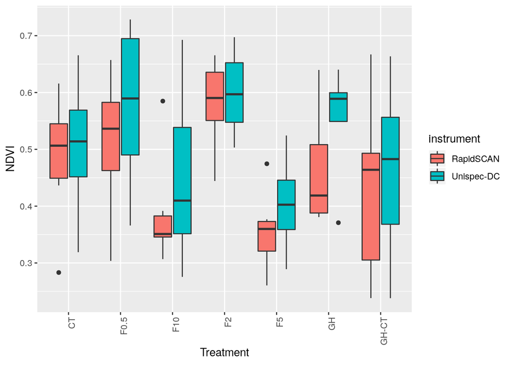